# Resident Canada Geese Vital Rates in the SE United States

Auriel M.V. Fournier  
Population Ecology Modeling Project

## Background

Canada Geese (*Branta canadensis*) have made a large comeback across much of the southern U.S (Balkcom 2010). Some of these individuals have become resident birds, and no longer regularly migrate along with the rest of the Canada Goose population. Resident birds create a special management concern for southern states because they often live in urban/suburban areas and cause human/wildlife conflicts. The Arkansas Game and Fish Commission has banded Canada Geese in Arkansas during the summer (when only resident geese are present) for ~20 years, and wants to determine if the liberalized hunting regulations of early season (September) Canada Geese have had an impact on the populations of resident Canada Geese in Arkansas. My hypothesis is that these hunts have had no impact because urban/suburban Canada Geese are not susceptible to hunting pressure and mortality would have to be very high to have an impact in the first place.

## Model Description

My original plan, and now longer term plan, is to analyze these results in a live-dead recapture model in RMark/Program Mark (White and Burnham 1999, Laake 2013). That part of the analysis has been put on hold for the moment by the other members of the project, so instead I here present the Lincoln results from the capture/recapture data from 2006-2013 and will examine vital rates from other southern resident goose populations to determine what might be driving the population dynamics of the resident Canada Geese in Arkansas.

The first model is a Lincoln estimator of abundance, which takes into account recovery rate of banded birds, reporting rate of banded birds and the harvest rate of the entire population. These numbers are correct to my knowledge, but one of the reasons the larger mark-recapture project is being held up is because of uncertainty with the origin and validity of the harvest estimates. The later model is a matrix model which examines changing of one part of the matrix in each scenario, varying it from 0 to 1.

## Results and Figures

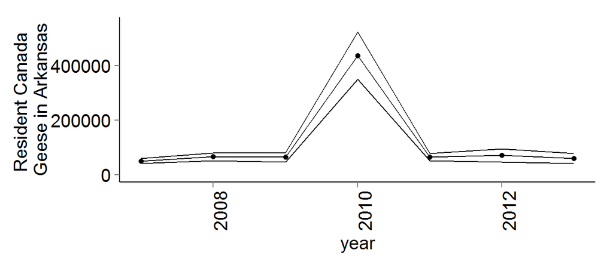

**Figure 1 - Lincoln Estimates of Adult Resident Canada Goose Populations from 2006-2013 in Arkansas**

The estimate of adult Canada Goose in 2010 has a higher estimate then the other years because Canada Goose harvest was much higher in 2010 (20k vs 2k), and we are not sure why since the regulations did not differ. If we remove 2010 we see that we have a fairly stable population.

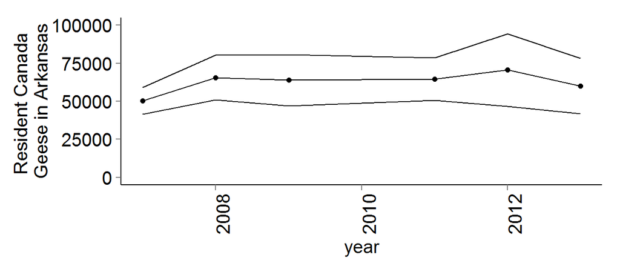

**Figure 2 - Lincoln Estimates of Adult Resident Canada Goose Populations from 2006-2013 in Arkansas, with 2010 removed because of unusually high harvest rates**

Our estimates seems logical and while the estimates vary over time the standard error shows that the population is not changing significantly (Missouri has ~40,000 resident Canada Geese, and Arkansas would expect to have similar numbers (Andy Raedeke, MDC, personal communication)). Arkansas Game and Fish Commission’s question of whether or not liberalized harvest in 2007 caused a decline in resident Canada Goose populations can be visually assessed with these two graphs, but further analysis is needed once we verify the harvest estimates. Based on Figure 2 the population is not declining, which is in line with other studies who have found that most suburban and urban resident Canada Goose populations are not impacted by hunting seasons, and so liberalizing (raising the bag limit and lengthening the season) does not cause a population decline (Arbaugh and Dixie 2010, Dunn and Jacobs (2000)).

For the moment, due to other collaborators on this project wanting to wait for additional information to take this forward, we are going to stop the analysis of Arkansas Canada Goose data here and instead throw out a wider net to resident Canada goose rates across the U.S.

I am going to examine the vital rates of urban resident Canada Geese in Georgia and other southeastern states (Balkcom 2010)). Urban geese present a unique problem because they are not susceptible to hunting mortality and often live in areas with increased food resources and in some cases decreased predator populations. Resident Canada Geese are defined as Canada Geese in the giant subspecies which do not perform yearly migrations, though one year old individuals may complete molt migrations where they complete one migration cycle but do not breeding during this time.

In Georgia and Pennsylvania additional hunting seasons have not been found to control the resident Canada Goose problem because urban geese, which make up most of resident goose populations, are not exposed to hunting pressure (Arbaugh and Dixie 2010, Dunn and Jacobs (2000)). ‘Hunting opportunity may be at or near the maximum sustainable rate for rural geese, yet sport hunting appears to have a small impact on urban geese’ (Balkcom 2010). One factor not taken into account in the following matrix model is differences in survival because of banding type. When gamebirds are banded with visual bands (such as neck bands) their survival declines because they are specifically targeted by hunters (survival of Canada Geese dropped from 82 to 67% in (Castelli and Trost 1996)). This increase in mortality is only found in non-urban geese, which are exposed to hunting pressure. Since I am modeling urban geese I did not include banding type in my model. When trying to control urban and suburban goose populations new challenges arrive because non-hunter removal of animals is very expensive, outside of cities hunters are the most cost effective method of animal removal as they pay to remove then, instead of having to pay others to do it (Conover 2001).

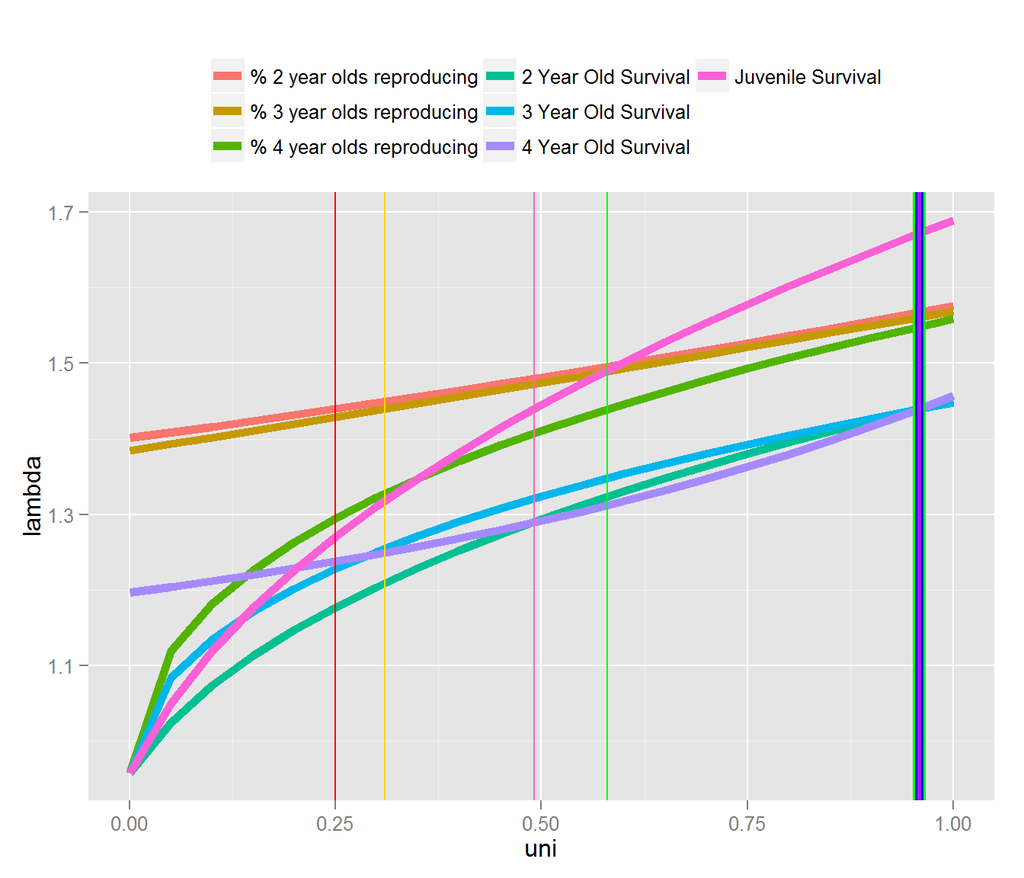

**Figure 3 - Variation in survival and breeding percentage for each age class of resident Canada Goose in the southeast**

## Conclusions

Based on these results a massive effort to reduce the survival of all age classes may be necessary to reduce lambda. Killing geese is not likely to be a publicly accepted option, and oiling goose eggs is very time consuming. Sterilizing male Canada geese surgically has been shown to be effective, sterile males still pair up and females lay infertile eggs (except where extra pair copulation take place) (Converse and Kennelly 1994). While this method would also be very time consuming and expensive (it does involve surgery) if it was done intensively for several years in a small area it could lower the population. Though just like in areas with Trap, Neuter, Release feral cat colonies, eventually the neutered cats die and new, fertile individuals take their place.

Managing urban wildlife populations is never easy, especially for species which can cause strong human-wildlife conflicts (goose scat on golf courses, aggressive geese chasing children, etc). Further work needs to be done to identify any weak spots in urban goose life histories since this analysis suggests that there are none. Work may also need to be done on helping to educate the public about animal removal, and understanding what methods the public is willing to accept when controlling urban wildlife populations.

## R Code

```r
library(ggplot2)
library(grid)

options(scipen=999)
m <- as.data.frame(matrix(c(2006,2007,2008,2009,2010,2011,2012,2013,980,807,741,938,1172,1498,1123,814,15,35,21,15,27,23,9,11),ncol=3))
colnames(m) <- c("year","banded","recovered")
m$recov_rate <- m$recovered/m$banded
m$recov_var <- ((m$recov_rate*(1-m$recov_rate))/(m$banded-1))
m$recov_se <- sqrt(m$recov_var)
m$report_rate <- 0.736
m$report_var <- .002
m$report_se <- .046
m$harvest_rate <- m$recov_rate/m$report_rate
m$harvest_var <- (m$recov_var/(m$report_rate^2))+(((m$recov_rate^2)*m$report_var)/(m$report_rate^4))
m$num_harvested <- c(0,4851,4139,2277,22425,2207,1261,1807)
m$adjust_harvested <- m$num_harvested*.61
m$N_Cago <- m$adjust_harvest/m$harvest_rate
m$N_var <- (0.1/(m$harvest_rate^2))+((m$adjust_harvested^2)*((m$harvest_var)/(m$harvest_rate^4)))
m$N_se <- sqrt(m$N_var)
m$N_ci_u <- m$N_Cago+m$N_se
m$N_ci_l <- m$N_Cago-m$N_se

options(scipen=999)# removes scientific notation from numbers
ggplot()+
  geom_point(data=m[m$year!=2006,], aes(x=year, y=N_Cago))+
  geom_line(data=m[m$year!=2006,], aes(x=year, y=N_Cago))+
  geom_line(data=m[m$year!=2006,], aes(x=year, y=N_ci_u))+
  geom_line(data=m[m$year!=2006,], aes(x=year, y=N_ci_l))+
  ylim(0,550000)+
  xlab("year")+
  ylab("Resident Canada \nGeese in Arkansas")+
  theme(plot.title = element_text(colour="black",size=15), #plot title
        axis.text.x = element_text(ang=90, colour="black", size=15), #x axis labels
        axis.text.y = element_text(colour="black",size=15), #y axis labels
        axis.title.x = element_text(colour="black",size=15),
        axis.title.y = element_text(colour="black",size=15), #y ,axis title
        legend.text = element_text(colour="black", size=15), #legend text
        legend.title = element_blank(),#legend title
        legend.background = element_rect(fill="white"), #legend background color
        legend.position = "top",
        legend.direction= "horizontal",
        legend.key = element_rect(colour="black", fill="white"),
        legend.key.width=unit(3,"cm"),
        plot.background = element_rect(fill = "white" ), #plot background color
        panel.grid.major= element_line(colour=NA),
        panel.grid.minor=element_line(colour=NA),
        panel.background = element_rect(fill = "white"),
        axis.line=element_line(colour="black"))

options(scipen=999)
ggplot()+
  geom_point(data=m[m$year!=2010&m$year!=2006,], aes(x=year, y=N_Cago))+
  geom_line(data=m[m$year!=2010&m$year!=2006,], aes(x=year, y=N_Cago))+
  geom_line(data=m[m$year!=2010&m$year!=2006,], aes(x=year, y=N_ci_u))+
  geom_line(data=m[m$year!=2010&m$year!=2006,], aes(x=year, y=N_ci_l))+
  ylim(0,100000)+
  xlab("year")+
  ylab("Resident Canada \nGeese in Arkansas")+
  theme(plot.title = element_text(colour="black",size=15), #plot title
        axis.text.x = element_text(ang=90, colour="black", size=15), #x axis labels
        axis.text.y = element_text(colour="black",size=15), #y axis labels
        axis.title.x = element_text(colour="black",size=15),
        axis.title.y = element_text(colour="black",size=15), #y ,axis title
        legend.text = element_text(colour="black", size=15), #legend text
        legend.title = element_blank(),#legend title
        legend.background = element_rect(fill="white"), #legend background color
        legend.position = "top",
        legend.direction= "horizontal",
        legend.key = element_rect(colour="black", fill="white"),
        legend.key.width=unit(3,"cm"),
        plot.background = element_rect(fill = "white" ), #plot background color
        panel.grid.major= element_line(colour=NA),
        panel.grid.minor=element_line(colour=NA),
        panel.background = element_rect(fill = "white"),
        axis.line=element_line(colour="black"))

mat <- matrix(c(0,.491,0,0,.25*2.3,0,0.958,0,.31*3.9, 0,0,0.958,.58*3.7,0,0,.958),ncol=4)

v <- matrix(nrow=4, ncol=100)

v[,1]<- c(20000*.25,20000*.25,20000*.24,20000*.26)

for(i in 1:99){

  v[,i+1] <- mat %*% v[,i]

}

col <- colSums(v)

eigens=eigen(mat)

lambda=eigens$values[1]
c=eigens$vectors[,1]/sum(eigens$vectors[,1])



## Variation in juvenile survival
lambdap0 <- matrix(nrow=1, ncol=21)
unip0 <- seq(0, 1,by=.05)
for(i in 1:21){
  mat <- matrix(c(0,unip0[i],0,0,.25*2.3,0,0.958,0,.31*3.9, 0,0,0.958,.58*3.7,0,0,.958),ncol=4)
eigenp0 <- eigen(mat)
lambdap0[i] <- eigenp0$values[1]
}
plot(unip0, lambdap0)

## variation in 2 year old survival
lambdap1 <- matrix(nrow=1, ncol=21)
unip1 <- seq(0, 1,by=.05)
for(i in 1:21){
  mat <- matrix(c(0,.491,0,0,.25*2.3,0,unip1[i],0,.31*3.9, 0,0,0.958,.58*3.7,0,0,.958),ncol=4)
eigenp1 <- eigen(mat)
lambdap1[i] <- eigenp1$values[1]
}
plot(unip1, lambdap1)

## variation in three year old survival
lambdap2 <- matrix(nrow=1, ncol=21)
unip2 <- seq(0, 1,by=.05)
for(i in 1:21){
  mat <- matrix(c(0,.491,0,0,.25*2.3,0,.958,0,.31*3.9, 0,0,unip2[i],.58*3.7,0,0,.958),ncol=4)
eigenp2 <- eigen(mat)
lambdap2[i] <- eigenp2$values[1]
}
plot(unip2, lambdap2)


## variation in four year old survival
lambdap3 <- matrix(nrow=1, ncol=21)
unip3 <- seq(0, 1,by=.05)
for(i in 1:21){
  mat <- matrix(c(0,.491,0,0,.25*2.3,0,.958,0,.31*3.9, 0,0,.958,.58*3.7,0,0,unip3[i]),ncol=4)
eigenp3 <- eigen(mat)
lambdap3[i] <- eigenp3$values[1]
}
plot(unip3, lambdap3)

## variation in percent of two year olds that reproduce
lambdap4 <- matrix(nrow=1, ncol=21)
unip4 <- seq(0, 1,by=.05)
for(i in 1:21){
  mat <- matrix(c(0,.491,0,0,unip4[i]*2.3,0,.958,0,.31*3.9, 0,0,.958,.58*3.7,0,0,.958),ncol=4)
eigenp4 <- eigen(mat)
lambdap4[i] <- eigenp4$values[1]
}
plot(unip4, lambdap4)


## variation in precent of three year olds that reproduce

lambdap5 <- matrix(nrow=1, ncol=21)
unip5 <- seq(0, 1,by=.05)
for(i in 1:21){
  mat <- matrix(c(0,.491,0,0,.25*2.3,0,.958,0,unip5[i]*3.9, 0,0,.958,.58*3.7,0,0,.958),ncol=4)
eigenp5 <- eigen(mat)
lambdap5[i] <- eigenp5$values[1]
}
plot(unip5, lambdap5)


## variation in precent of four year olds that reproduce
lambdap6 <- matrix(nrow=1, ncol=21)
unip6 <- seq(0, 1,by=.05)
for(i in 1:21){
  mat <- matrix(c(0,.491,0,0,.25*2.3,0,.958,0,.31*3.9, 0,0,.958,unip6[i]*3.7,0,0,.958),ncol=4)
eigenp6 <- eigen(mat)
lambdap6[i] <- eigenp6$values[1]
}
plot(unip6, lambdap6)

dat <- as.numeric(cbind(lambdap0, lambdap1, lambdap2, lambdap3,lambdap4, lambdap5, lambdap6))
uni <- as.numeric(rep(unip0, times=7))
scen <- as.factor(rep(c("Juvenile Survival","2 Year Old Survival","3 Year Old Survival","4 Year Old Survival","% 2 year olds reproducing","% 3 year olds reproducing","% 4 year olds reproducing"), each=21))

data <- as.data.frame(rbind(dat, uni))
tran <- as.data.frame(t(data))
tran2 <- cbind(tran, scen)
library(reshape)

mdat <- melt(tran2, id=c("scen","uni"))

col <- c("#ffffcc","#c7e9b4","#7fcdbb","#41b6c4","#1d91c0","#225ea8","#0c2c84")

ggplot()+
  geom_line(data=mdat, aes(x=uni, y=value, group=scen,  colour=scen), size=2)+
  ylab("lambda")+
  geom_vline(xintercept=.491, col="hot pink")+geom_vline(xintercept=.58, col="green")+geom_vline(xintercept=.31, col="gold")+geom_vline(xintercept=.25, col="red")+geom_vline(xintercept=.958, col="green", size=3)+geom_vline(xintercept=.958, col="blue", size=2)+geom_vline(xintercept=.958, col="purple", size=1)+
  theme(legend.position="top",
        legend.title=element_blank())+
  guides(col=guide_legend(nrow=3))
```

References

Arbaugh, J. A. S. C., and N. Dixie. 2010. Nest-site selection and nesting ecology of giant Canada geese in central Tennessee. Human–Wildlife Interactions 4:207–212.

Balkcom, G. D. 2010. Demographic Parameters of Rural and Urban Adult Resident Canada Geese in Georgia. Journal of Wildlife Management 74:120–123.

Castelli, P. M., and R. E. Trost. 1996. Neck Bands Reduce Survival of Canada Geese in New Jersey. The Journal of Wildlife Management 60:891–898.

Conover, M. R. 2001. Effect of hunting wildlife and damage trapping. The Wildlife Society Bulletin 29:521–532.

Converse, K. A., and J. J. Kennelly. 1994. Evaluation of Canada Goose Sterilization for Population Control. Wildlife Society Bulletin 22:265–269.

Dunn, J. P., and K. J. Jacobs. 2000. Special resident Canada goose hunting seasons in Pennsylvania - management implications for controlling resident Canada geese. The Ninth Wildlife Damage Management Conference Proceedings:322–336.

Eberhardt, L. E., R. G. Anthony, and W. H. Rickard. 1989. Survival of Juvenile Canada Geese During the Rearing Period. The Journal of Wildlife Management 53:372–377.

Laake, J. L. 2013. RMark : An R Interface for Analysis of Capture-Recapture Data with Mark. Page 25. Alaska Fish Science Center, NOAA.

Raveling, D. G. 1981. Survival, Experience and Age in Relation to Breeding Success of Canada Geese. The Journal of Wildlife Management 45:817–829.

White, G. C., and K. Burnham. 1999. Program MARK: Survival Estimation from populations of marked animals. Bird Study 46 Supplem:120–138.